# Plotting Assigment #5

- Show All Code
- Hide All Code
- View Source

Time Series

Author

Haley Brumberger

Published

March 2, 2026

# 1 Setup

Using R version 4.5.2 (2025-10-31) , R Core Team (2022), and ggplot2 version 4.0.0 from the tidyverse (Wickham et al. 2019).

```r
# load packages, tidyverse includes lubridate
library(tidyverse)

# install arrow package
#install.packages("arrow") # run this only if you don't have the arrow package installed
library(arrow)

# load script files
source("scripts/plotting_functions.R")
```

# 2 Data

```r
# load fire data, make sure it's a tibble, save to "fires" variable
fires <- as_tibble(arrow::read_parquet("data/fires.parquet"))
```

# 3 Plots

## 3.1 Plot 1 – Total Fires Every Day

Figure 1 displays how many fires occurred each day between 1992 and 2015. It appears that there were, relatively speaking, more days with 300 or fewer fires given how densely the lower/yellow bars are populated along the x-axis. However, there were definitely more days with 600+ fires than I was expecting. The days with the most fires had over 1000 fires, which feels like a lot considering this is data only from the United States.

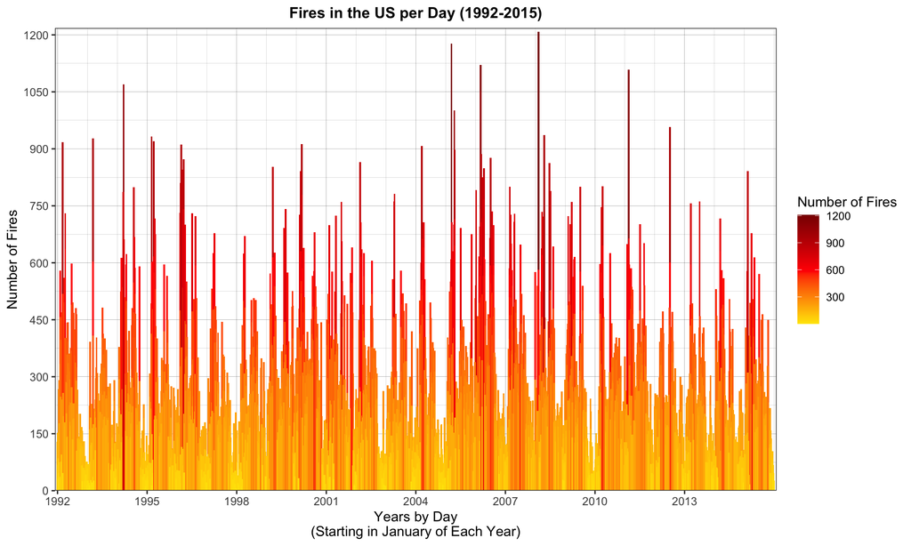

Figure 1: Bar plot showing the number of fires per day every year from 1992 through 2015. X-axis ticks represent January 1st of each year; the legend and y-axis both represent numbers of fires, but do so differently from one another (y-axis is height, legend is color).

```r
# create new tibble with fires per day, every day of the dataset, and adding an n column to total up the # of fires
fires_by_date <- fires |>
  summarize(.by = discovery_date, n = n()) # making new fire dataset organized by date, adding an n column to keep track of how many entries there were on that date

fires_by_date |>
  ggplot() +
  aes(x = discovery_date, y = n, fill = n) +
  geom_col(width = 22) + # if the width is too small, bars won't show up because they are so skinny bc the x-axis is so many days; 22 seems to make sure they all appear and are readily visible
  scale_fill_gradientn(
    colors = c("#ffe600ff", "red", "darkred"), # gradient from orangey yellow -> red -> dark red to look cool/like fire
    name = "Number of Fires"
  ) +
  scale_x_date(
    breaks = seq(ymd("1992-01-01"), ymd("2015-12-31"), "3 years"), # setting the date bounds for the x axis and the major breaks at 3 yrs
    date_labels = "%Y", # showing year in the x axis text
    date_minor_breaks = "1 year", # breaking every 1 year
    expand = expansion(add = c(20, 20)) # setting the x axis bounds expand 20 days so the first and last bars are basically flush with the plot extent, but not squished
  ) +
  scale_y_continuous(
    breaks = seq(0, 1215, 150),
    expand = expansion(add = c(0, 10)) # setting the vertical bars to start flush against the x-axis, but leave some space at the top
  ) +
  theme_bw() +
  labs(
    x = "Years by Day\n(Starting in January of Each Year)",
    y = "Number of Fires",
    title = "Fires in the US per Day (1992-2015)"
  ) +
  theme(
    # pretty-ifying the plot
    panel.grid.major.x = element_line(color = "black", linewidth = 0.05),
    panel.grid.minor.x = element_line(color = "black", linewidth = 0.025),
    panel.grid.major.y = element_line(color = "black", linewidth = 0.05),
    panel.grid.minor.y = element_line(color = "black", linewidth = 0.025),
    plot.title = element_text(hjust = 0.5, face = "bold", size = 12),
    axis.title = element_text(size = 11),
    axis.text = element_text(size = 9)
  )
```

## 3.2 Plot 2 – Total Fires by Year

Figure 2 has three panels: the top one is the number of fires per year (in numbers that are divided by 1000); the middle one is average fire size in acres, and the bottom one is average fire duration in hours. The data spans from 1992 through 2015. The highest number of fires in a year was ~114,000, compared to the lowest at ~61,000–almost 1/2 the amount. Interestingly, all three datasets show positively correlated data via lines of best fit, where as year increased overall, so too did the parameter being represented. However, the data fluctuates significantly in all three plots. One outlier in the average duration plot sits around 120 hours, which is 2-5x longer than any of the other years. Though the average fire size for that year (2014) was actually on the lower end, when looking at the data table itself, it becomes apparent that there were more small but long fires in 2014 (longer on average than any of the other years).

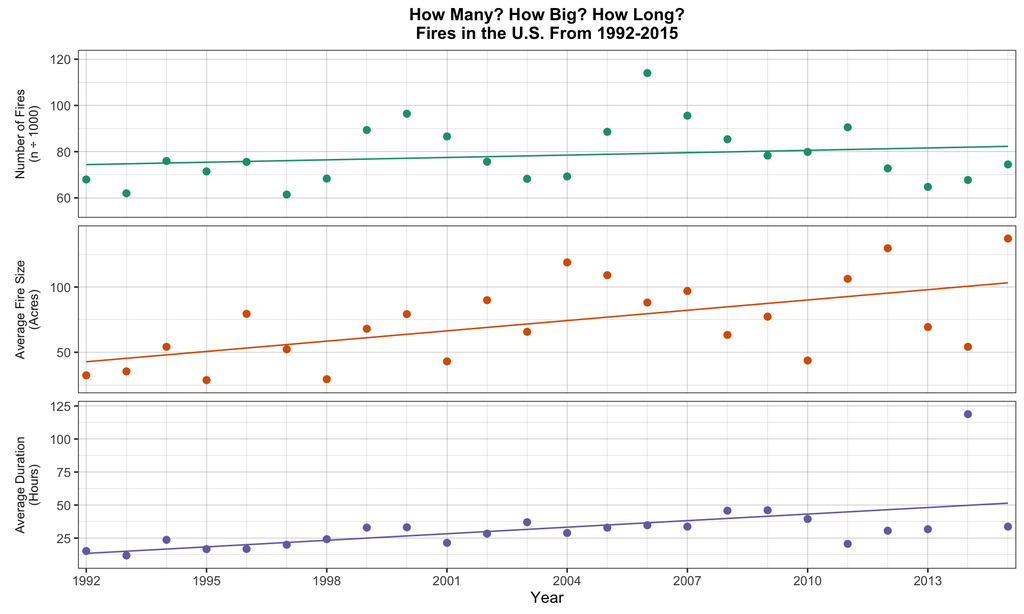

Figure 2: Scatterplot showing the number of fires per year (numbers are divided by 1000 for ease of axis reading) stacked on top of the average fire size (in acres) and average duration (in hours). Lines of best fit show positive/increasing trends in the three datasets.

```r
fires_by_year <- fires |> # creating a new tibble with fires grouped by year and new columns of: fires/year divided by 1000 for a more manageable number, fire_size, and days_til_contained
  mutate(
    year = discovery_date |> year() |> make_date(),
    contained_after = contained_after / dhours(1)
  ) |>
  summarize(
    .by = "year",
    n = (n() / 1000),
    fire_size = mean(fire_size),
    contained_after = mean(contained_after, na.rm = TRUE)
  )
# pivoting fires_by_year longer to make it easier to facet the plots
fires_by_year_long <- fires_by_year |>
  pivot_longer(
    cols = c("n", "fire_size", "contained_after"),
    names_to = "metrics",
    values_to = "values"
  )

# recoding the factors to be more intuitive and pretty
fires_by_year_long_fct <- fires_by_year_long |>
  mutate(
    metrics = metrics |>
      as_factor() |>
      fct_recode(
        "Number of Fires\n(n \U00F7 1000)" = "n", # adding "divided by 1000" using the Unicode for the division symbol to the factor for n since I divided the number of fires by 1000 when making the dataset
        "Average Fire Size\n(Acres)" = "fire_size",
        "Average Duration\n(Hours)" = "contained_after"
      )
  )

# plotting
fires_by_year_long_fct |>
  ggplot() +
  aes(x = year, y = values, color = metrics) +
  geom_point(size = 2) +
  facet_wrap(~metrics, ncol = 1, scales = "free_y", strip.position = "left") + # making the y scales independent and putting the strip titles on the left / y axis so that units are clear
  scale_x_date(
    breaks = seq(ymd("1992-01-01"), ymd("2016-01-01"), "3 years"),
    date_labels = "%Y",
    date_minor_breaks = "1 year",
    expand = expansion(add = c(75, 75)) # adding space to either side of the x axis so points don't get cut off
  ) +
  scale_y_continuous(expand = expansion(add = c(10, 10))) + # making the y axis a little bigger to show some space above/below the lowest/highest points +
  geom_smooth(method = "lm", formula = y ~ x, se = FALSE, linewidth = 0.5) + # adding lines of best fit
  theme_bw() +
  scale_color_brewer(palette = "Dark2") + # color blind friendly palette
  labs(
    title = "How Many? How Big? How Long?\nFires in the U.S. From 1992-2015",
    x = "Year",
  ) +
  theme(
    # pretty-ifying the plot
    panel.grid.major.x = element_line(color = "black", linewidth = 0.05),
    panel.grid.minor.x = element_line(color = "black", linewidth = 0.025),
    panel.grid.major.y = element_line(color = "black", linewidth = 0.05),
    panel.grid.minor.y = element_line(color = "black", linewidth = 0.025),
    plot.title = element_text(hjust = 0.5, face = "bold", size = 12),
    axis.title.x = element_text(size = 11),
    axis.title.y = element_blank(), # taking away the y axis label since each one is different
    axis.text = element_text(size = 9),
    legend.position = "None",
    strip.placement = "outside", # putting the titles outside of the axis text
    strip.background = element_blank() # getting rid of the grey strip title background so they blend more
  )
```